# HIFIVE Analysis

Alec Xia

2024-07-31

# 1 Research Question

- Is there a difference in the average rates of total symptoms between HEPA and control groups?

## 1.1 Context to Consider

- Seasonality of cold, flu, and allergy symptoms
- Random assignment to treatment and control
- Small number of participants that may still lead to imbalances after random assignment
- Participants were enrolled at different times of the year and participated for different durations

# 2 Analysis Flow

- Using Generalized Additive Mixed-Effect Model (GAMM) to account for correlated data structure and to add a smoother for weeks.

## 2.1 Any covariates to include?

- Examined whether the treatment and control groups are different in age, sex, insurance type, race, family education, household income, asthma (yes/no), allergies (yes/no), enrollment week (in calendar week), duration.
- Decided to not include other covariates beside duration and enrollment week.

|  | 0 (N=12) | 1 (N=7) | Total (N=19) | p value |
| --- | --- | --- | --- | --- |
| **Sex** |  |  |  | 0.817 |
| Female | 3 (25.0%) | 1 (14.3%) | 4 (21.1%) |  |
| Male | 8 (66.7%) | 5 (71.4%) | 13 (68.4%) |  |
| Prefer not to answer | 1 (8.3%) | 1 (14.3%) | 2 (10.5%) |  |
| **Age in Years** |  |  |  | 0.834 |
| Mean (SD) | 8.917 (1.730) | 8.714 (2.430) | 8.842 (1.951) |  |
| Range | 6.000 - 11.000 | 5.000 - 11.000 | 5.000 - 11.000 |  |
| **Aggregated Child Race** |  |  |  | 0.138 |
| Black/African-American | 5 (41.7%) | 0 (0.0%) | 5 (26.3%) |  |
| Other | 5 (41.7%) | 5 (71.4%) | 10 (52.6%) |  |
| White/Caucasian | 2 (16.7%) | 2 (28.6%) | 4 (21.1%) |  |
| **Child Ethnicity** |  |  |  | 0.234 |
| No | 6 (50.0%) | 1 (14.3%) | 7 (36.8%) |  |
| Prefer not to answer | 2 (16.7%) | 1 (14.3%) | 3 (15.8%) |  |
| Yes | 4 (33.3%) | 5 (71.4%) | 9 (47.4%) |  |
| **Parent Health Insurance Type** |  |  |  | 0.764 |
| Private | 6 (50.0%) | 3 (42.9%) | 9 (47.4%) |  |
| Public | 6 (50.0%) | 4 (57.1%) | 10 (52.6%) |  |
| **Parent Education** |  |  |  | 0.495 |
| Less than high school graduate | 0 (0.0%) | 2 (28.6%) | 2 (10.5%) |  |
| High school graduate/ GED (or equivalent) | 2 (16.7%) | 0 (0.0%) | 2 (10.5%) |  |
| Some college (1-4 years, no degree) | 2 (16.7%) | 1 (14.3%) | 3 (15.8%) |  |
| Associate’s degree (including occupational or academic degrees) | 4 (33.3%) | 2 (28.6%) | 6 (31.6%) |  |
| Bachelor’s degree (BA, BS, AB, etc.) | 2 (16.7%) | 1 (14.3%) | 3 (15.8%) |  |
| Master’s degree (MA, MS, MENG, MSW, etc.) | 1 (8.3%) | 1 (14.3%) | 2 (10.5%) |  |
| Doctorate degree (PhD, EdD, etc.) | 1 (8.3%) | 0 (0.0%) | 1 (5.3%) |  |
| **Household Income** |  |  |  | 0.286 |
| N-Miss | 2 | 3 | 5 |  |
| Less than $23,000 | 0 (0.0%) | 1 (25.0%) | 1 (7.1%) |  |
| Between $46,000 and $70,000 | 4 (40.0%) | 0 (0.0%) | 4 (28.6%) |  |
| More than $70,000 | 4 (40.0%) | 2 (50.0%) | 6 (42.9%) |  |
| Prefer not to answer | 1 (10.0%) | 1 (25.0%) | 2 (14.3%) |  |
| Don’t know | 1 (10.0%) | 0 (0.0%) | 1 (7.1%) |  |
| **Asthma** |  |  |  | 0.363 |
| No | 4 (33.3%) | 1 (14.3%) | 5 (26.3%) |  |
| Yes | 8 (66.7%) | 6 (85.7%) | 14 (73.7%) |  |
| **Allergies** |  |  |  | 0.960 |
| No | 5 (41.7%) | 3 (42.9%) | 8 (42.1%) |  |
| Yes | 7 (58.3%) | 4 (57.1%) | 11 (57.9%) |  |
| **Enrollment Week in Calendar Weeks** |  |  |  | 0.430 |
| Mean (SD) | 10.917 (7.440) | 8.143 (6.768) | 9.895 (7.141) |  |
| Range | 4.000 - 23.000 | 4.000 - 23.000 | 4.000 - 23.000 |  |
| **Duration** |  |  |  | 0.803 |
| Mean (SD) | 8.833 (3.927) | 9.286 (3.402) | 9.000 (3.651) |  |
| Range | 2.000 - 11.000 | 2.000 - 11.000 | 2.000 - 11.000 |  |

## 2.2 Starting Model

- Model Equation:
  $$log(\mu_{ij}) = \beta_0 + \beta_1 (duration)_{i} + \beta_2 (timing)_{i}
  + \beta_3 (treatment)_{i} + f_1(week_{ij}) + b_{0i}$$

where

$i$ is the the $ith$ participant, $j$ is the $jth$ repeated measurement

$\beta_0$ = the population intercept;

$\beta_1$ = main effect of duration (in weeks);

$\beta_2$ = main effect of enrollment timing (in calendar weeks);

$\beta_3$ = main effect of treatment;

$f_1$ = a cubic spline with normal second derivative penalty;

$b_0$ = individual participant random intercept.

- Started with a Poisson GAMM using gamm4 package. The underlying engine for mixed effect model is lme4.

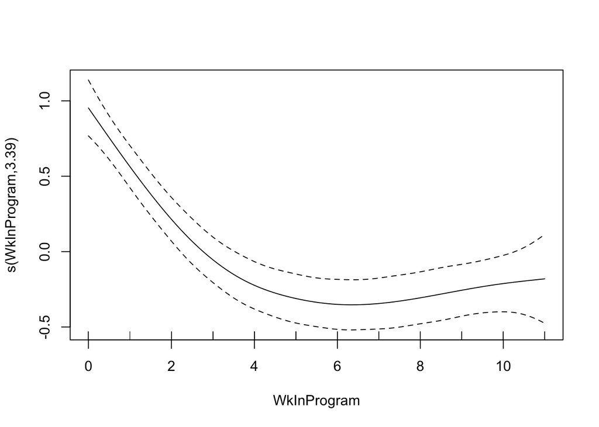

```r
HIFIVE.long$Record.ID <- as.character(HIFIVE.long$Record.ID)
fit0 <- gamm4(TotSymptoms~duration + EnrlWk + HEPA + s(WkInProgram, bs = "cr"), random = ~ (1|Record.ID), data = HIFIVE.long, family = poisson(link = "log"))
plot(fit0$gam)
```

```r
summary(fit0$mer)
```

```
## Generalized linear mixed model fit by maximum likelihood (Laplace
##   Approximation) [glmerMod]
##  Family: poisson  ( log )
##
##      AIC      BIC   logLik deviance df.resid
##    723.2    745.9   -354.6    709.2      183
##
## Scaled residuals:
##     Min      1Q  Median      3Q     Max
## -2.1984 -0.9071 -0.3995  0.4224  4.3550
##
## Random effects:
##  Groups    Name           Variance Std.Dev.
##  Record.ID (Intercept)    0.914371 0.9562
##  Xr        s(WkInProgram) 0.001143 0.0338
## Number of obs: 190, groups:  Record.ID, 19; Xr, 8
##
## Fixed effects:
##                    Estimate Std. Error z value Pr(>|z|)
## X(Intercept)        3.27913    2.54003   1.291    0.197
## Xduration          -0.19343    0.17680  -1.094    0.274
## XEnrlWk            -0.12091    0.09197  -1.315    0.189
## XHEPA1              0.06217    0.51416   0.121    0.904
## Xs(WkInProgram)Fx1  0.96554    0.15250   6.331 2.43e-10 ***
## ---
## Signif. codes:  0 '***' 0.001 '**' 0.01 '*' 0.05 '.' 0.1 ' ' 1
##
## Correlation of Fixed Effects:
##             X(Int) Xdurtn XEnrlW XHEPA1
## Xduration   -0.982
## XEnrlWk     -0.965  0.926
## XHEPA1      -0.405  0.313  0.367
## Xs(WkInP)F1 -0.024  0.026  0.003  0.000
```

## 2.3 Overdispersion

From a first glimpse, the data may not fit Poisson distribution:

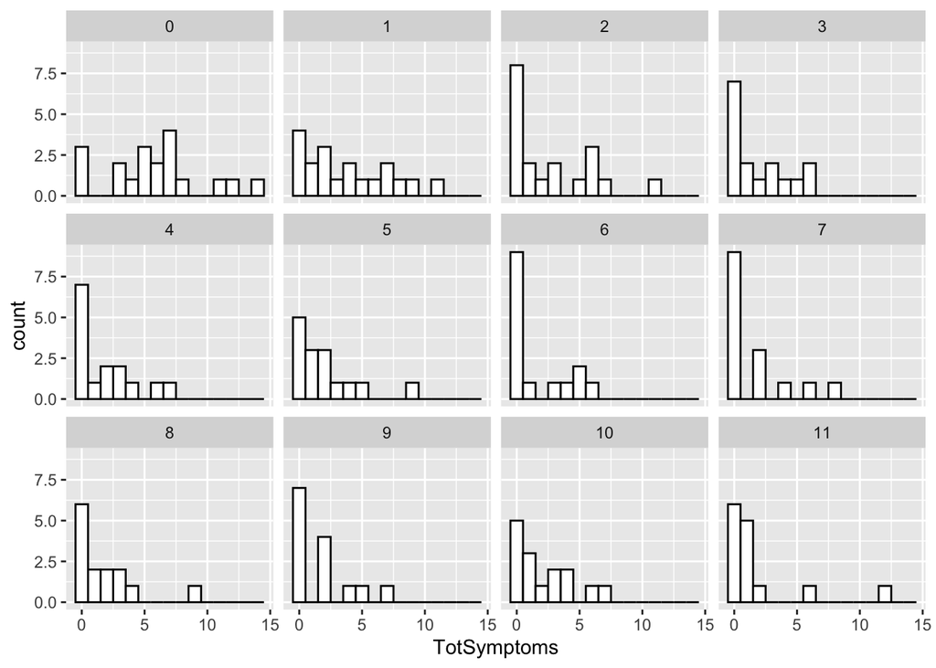

```r
ggplot(HIFIVE.long, aes(x = TotSymptoms)) +
  geom_histogram(binwidth = 1, color = "black", fill = "white") +
  facet_wrap(HIFIVE.long$WkInProgram~.)
```

- Checked overdispersion of the Poisson GAMM model using squared Pearson residuals.

```r
overdisp_fun <- function(model) {
    rdf <- df.residual(model)
    rp <- residuals(model,type="pearson")
    Pearson.chisq <- sum(rp^2)
    prat <- Pearson.chisq/rdf
    pval <- pchisq(Pearson.chisq, df=rdf, lower.tail=FALSE)
    c(chisq=Pearson.chisq,ratio=prat,rdf=rdf,p=pval)
}
overdisp_fun(fit0$mer)
```

```
##        chisq        ratio          rdf            p
## 2.518648e+02 1.376310e+00 1.830000e+02 5.553721e-04
```

- Pearson residuals showed overdispersion for Poisson GAMM.

## 2.4 Negative Binomial GAMM model

- To remedy the overdispersion, I switched to use negative binomial GAMM to model the data.
- gamm4 is currently restricted to using families specified in glmer or lmer, which requires specification of parameter $\theta$ for the negative binomial model to initiate.
- I followed the protocol used in glmer.nb, where I used ML estimation for $\theta$ based on fitted poisson model. (MASS library: theta.ml) Then, I used ML estimated $\hat{\theta}$ to initiate the negative binomial model.

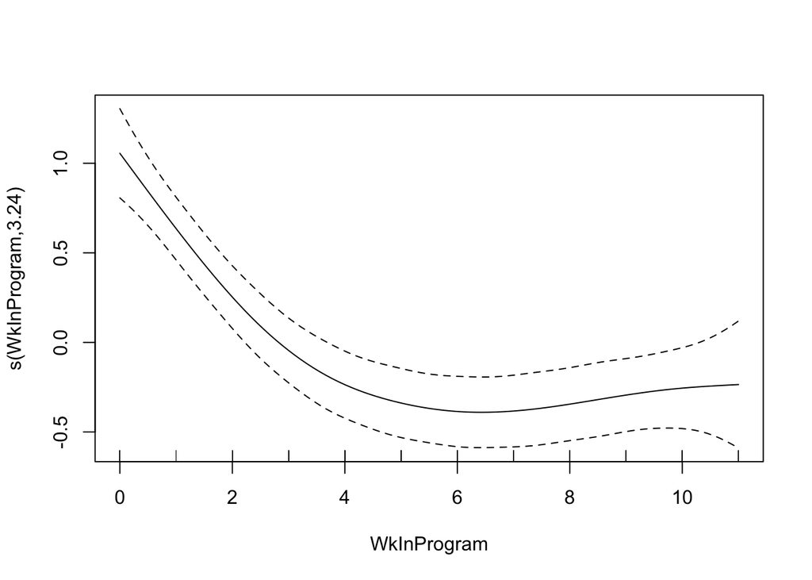

```r
mu <- fitted(fit0$mer)
y <- HIFIVE.long$TotSymptoms
th <- MASS::theta.ml(y, mu)
fit1 <- gamm4(TotSymptoms~duration + EnrlWk + HEPA + s(WkInProgram, bs = "cr"), random = ~ (1|Record.ID), data = HIFIVE.long, family = negative.binomial(theta = th[1], link = "log")) # refit to a negative binomial model
plot(fit1$gam)
```

- Using Pearson residual tests, I did not see any more significant overdispersion in the negative binomial model.

```r
overdisp_fun(fit1$mer)
```

```
##       chisq       ratio         rdf           p
## 192.2667145   1.0564105 182.0000000   0.2866784
```

```r
summary(fit1$mer)
```

```
## Generalized linear mixed model fit by maximum likelihood (Laplace
##   Approximation) [glmerMod]
##  Family: Negative Binomial(6.8947)  ( log )
##
##      AIC      BIC   logLik deviance df.resid
##    706.2    732.2   -345.1    690.2      182
##
## Scaled residuals:
##     Min      1Q  Median      3Q     Max
## -1.5732 -0.7938 -0.3837  0.4108  3.9655
##
## Random effects:
##  Groups    Name           Variance Std.Dev.
##  Record.ID (Intercept)    0.95180  0.97560
##  Xr        s(WkInProgram) 0.00144  0.03795
## Number of obs: 190, groups:  Record.ID, 19; Xr, 8
##
## Fixed effects:
##                     Estimate Std. Error z value Pr(>|z|)
## X(Intercept)        3.316426   0.007786 425.930   <2e-16 ***
## Xduration          -0.193508   0.007520 -25.732   <2e-16 ***
## XEnrlWk            -0.126591   0.007291 -17.363   <2e-16 ***
## XHEPA1              0.003744   0.007770   0.482     0.63
## Xs(WkInProgram)Fx1  1.108500   0.007808 141.964   <2e-16 ***
## ---
## Signif. codes:  0 '***' 0.001 '**' 0.01 '*' 0.05 '.' 0.1 ' ' 1
##
## Correlation of Fixed Effects:
##             X(Int) Xdurtn XEnrlW XHEPA1
## Xduration   -0.008
## XEnrlWk     -0.008 -0.051
## XHEPA1      -0.002 -0.005 -0.004
## Xs(WkInP)F1 -0.001 -0.014 -0.005  0.001
```

## 2.5 Model Checking

For model checking, there are limited resources for GAMM. I used DHARMa package, which employs a simulation based approach for model checking. Briefly, the model checking works as follows:

- I started with producing a set of simulated residuals, and plotting the residuals in uniform QQ plot and against predicted values.

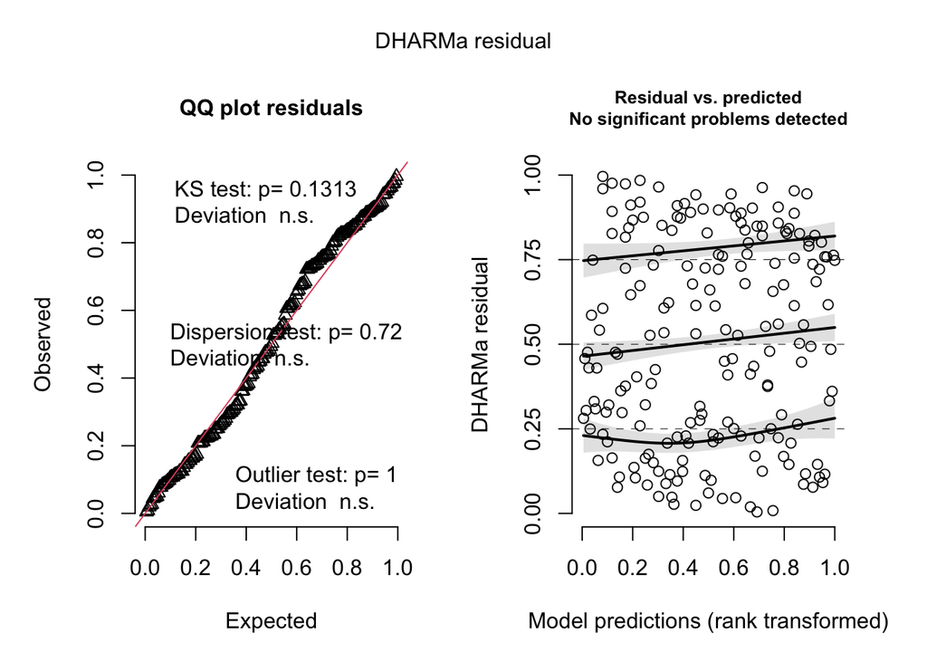

```r
library(DHARMa)
simulationOutput <- simulateResiduals(fit1$mer)
plot(simulationOutput) # Looks like the model fits well overall.
```

- Then I examined the residuals against each predictor.

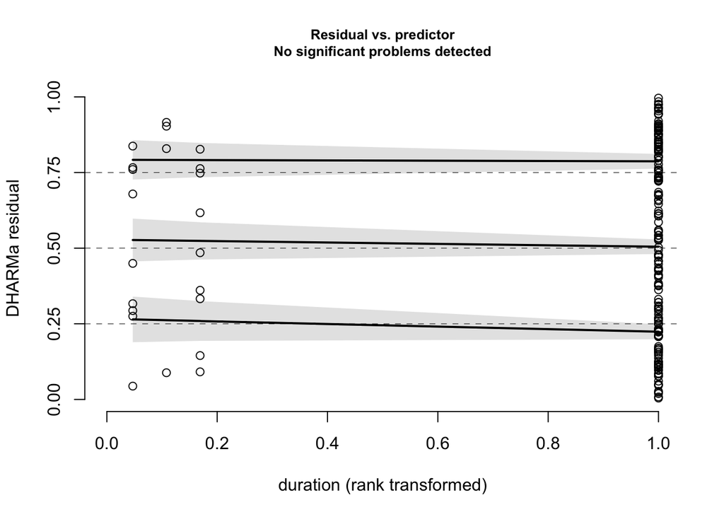

```r
plotResiduals(simulationOutput, HIFIVE.long$duration, asFactor = F)
```

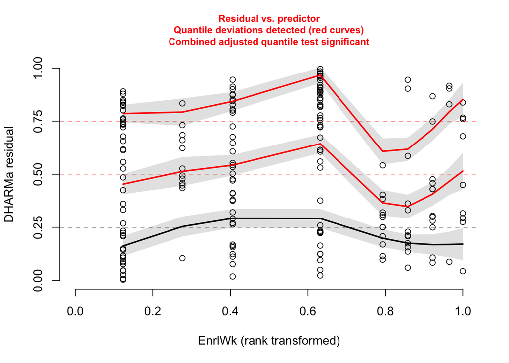

```r
plotResiduals(simulationOutput, HIFIVE.long$EnrlWk, asFactor =  F)
```

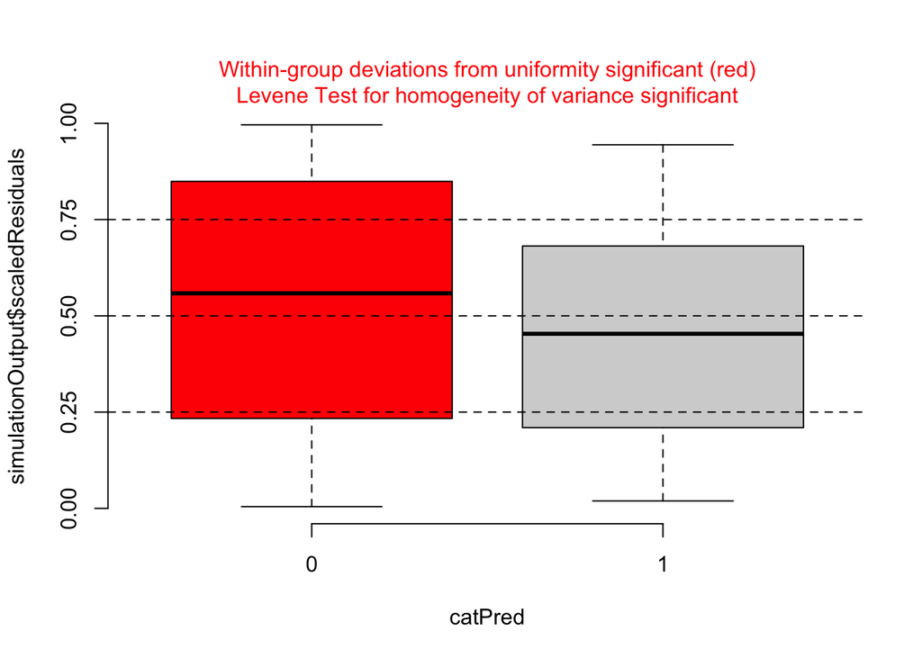

```r
plotResiduals(simulationOutput, HIFIVE.long$HEPA)
```

- Lastly, I conducted formal tests against zero inflation and overdispersion.

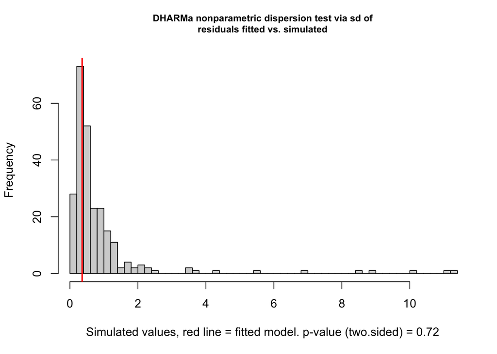

```
##
##  DHARMa nonparametric dispersion test via sd of residuals fitted vs.
##  simulated
##
## data:  simulationOutput
## dispersion = 0.40103, p-value = 0.72
## alternative hypothesis: two.sided
```

```r
testDispersion(simulationOutput)
```

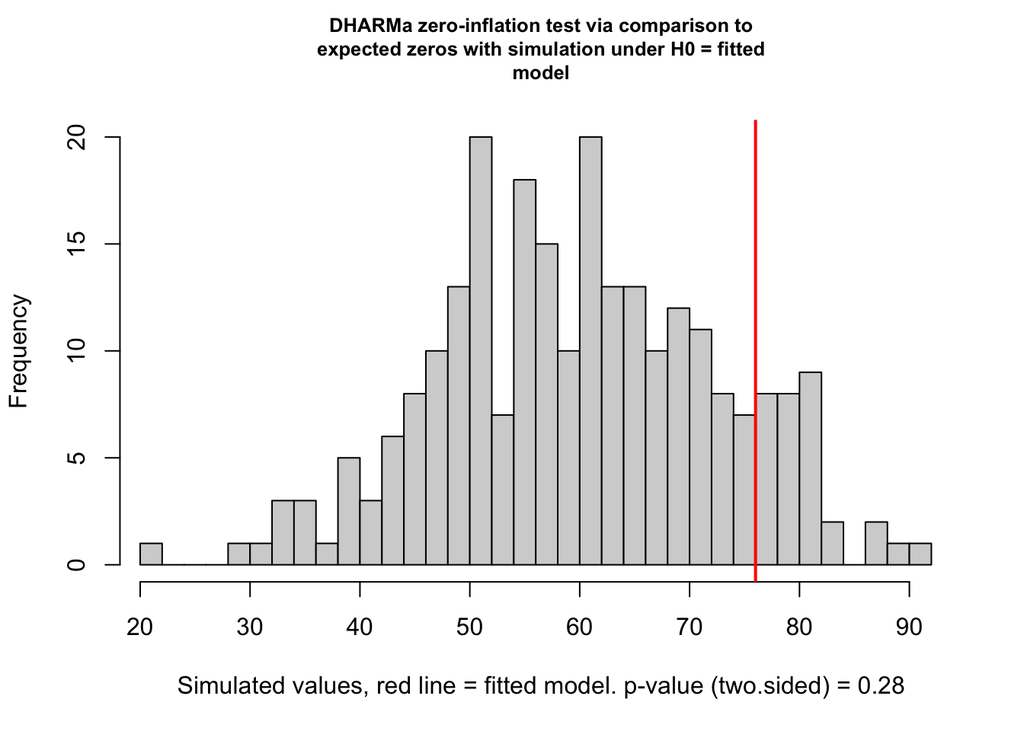

```
##
##  DHARMa zero-inflation test via comparison to expected zeros with
##  simulation under H0 = fitted model
##
## data:  simulationOutput
## ratioObsSim = 1.2592, p-value = 0.28
## alternative hypothesis: two.sided
```

```r
testZeroInflation(simulationOutput)
```